# Kaggle Titanic

This is a replica of [Megan Risdal’s post, Exploring Survival on the Titanic](https://www.kaggle.com/mrisdal/exploring-survival-on-the-titanic), with a bit more [tidyverse](https://www.tidyverse.org/) style to make the code clearer.

# Load Packages and Data

```r
# Load packages
library(tidyverse)
library(mice)
library(randomForest)
library(stringr)
library(scales)
# Load data
train <- read_csv('./input/train.csv');
test <- read_csv('./input/test.csv');
full <- bind_rows(train=train, test=test, .id = 'dataset');
```

# Feature Engineering

## People’s Titles

#### Extract title from names

```r
full <- full %>% mutate(Title=str_replace_all(Name, '(.*, )|(\\..*)', ''))
table(full$Sex, full$Title)
```

```
         Capt Col Don Dona  Dr Jonkheer Lady Major Master Miss Mlle Mme  Mr Mrs  Ms Rev Sir the Countess
  female    0   0   0    1   1        0    1     0      0  260    2   1   0 197   2   0   0            1
  male      1   4   1    0   7        1    0     2     61    0    0   0 757   0   0   8   1            0
```

#### Duplicated titles

Some titles mean the same thing, like Miss = Ms = Mlle, and Mme = Mrs. Combine them.

```r
full <- full %>%
    mutate_at(.vars = vars(Title),
              .funs = funs(ifelse(. %in% c('Mlle','Ms'), 'Miss', .))) %>%
    mutate_at(.vars = vars(Title),
              .funs = funs(ifelse(. %in% c('Mme'), 'Mrs', .)))
```

#### Rare titles

Some titles are quite rare. Combine them to one label, ‘Rare Title’

```r
title_counts <- table(full$Title)
rare_title <- names(title_counts)[title_counts<10]
full <- full %>% mutate_at(.vars = vars(Title),
                           .funs = funs(ifelse(. %in% rare_title, 'Rare Title', .)))
table(full$Sex, full$Title)
```

```
         Master Miss  Mr Mrs Rare Title
  female      0  264   0 198          4
  male       61    0 757   0         25
```

## Families

#### Family names

Get family names from full names

```r
full$Surname <- full$Name %>% str_split('[,.]') %>% lapply('[[', 1) %>% unlist() %>% trimws()
```

#### Family size

Get family sizes from counts of sibling, spouse, parents, and children

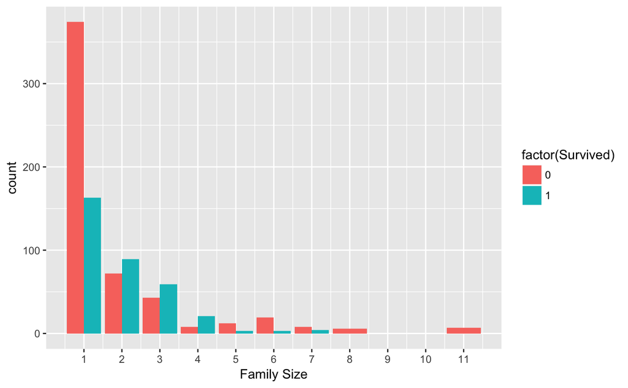

```r
full <- full %>%
    mutate(Fsize = SibSp + Parch +1) %>%
    mutate(Family = paste(Surname, Fsize, sep='_'))
ggplot(data = subset(full, !is.na(Survived)),
       aes(x = Fsize, fill=factor(Survived))) +
    geom_bar(stat = 'count', position = 'dodge') +
    scale_x_continuous(breaks = 1:11) +
    labs(x = 'Family Size')
```

#### Singleton, samll, and large families

Categorize family sizes into ‘singleton’, ‘small’, and ‘large’

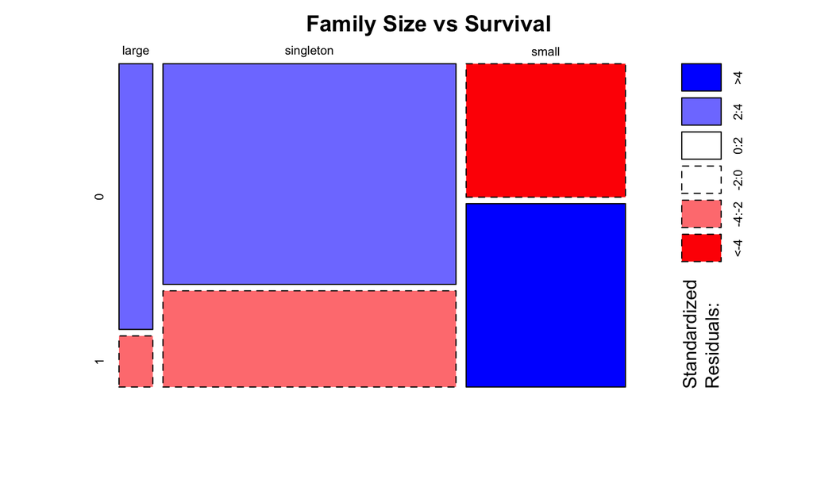

```r
full <- full %>% mutate(FsizeD = case_when(
    Fsize==1 ~ 'singleton',
    Fsize>4 ~ 'large',
    TRUE ~ 'small'
))
mosaicplot(table(full$FsizeD, full$Survived), main='Family Size vs Survival', shade = TRUE)
```

Looks like small families are more likely to survive.

## Deck

Deck information is available from the `Cabin` code

```r
full$Deck <-  full$Cabin %>% substr(1,1) %>% as.factor()
```

## Missing Values

#### Count `NA`’s

```r
full %>% is.na() %>% colSums()
```

```
    dataset PassengerId    Survived      Pclass        Name         Sex         Age       SibSp       Parch
          0           0         418           0           0           0         263           0           0
     Ticket        Fare       Cabin    Embarked       Title     Surname       Fsize      Family      FsizeD
          0           1        1014           2           0           0           0           0           0
       Deck
       1014
```

#### Missing `Embarked`

```r
selector <- full$Embarked %>% is.na()
full[selector, ]
```

| dataset | PassengerId | Survived | Pclass | Name | Sex | Age | SibSp | Parch | Ticket | Fare | Cabin | Embarked | Title | Surname | Fsize | Family | FsizeD | Deck |
| --- | --- | --- | --- | --- | --- | --- | --- | --- | --- | --- | --- | --- | --- | --- | --- | --- | --- | --- |
| train | 62 | 1 | 1 | Icard, Miss. Amelie | female | 38 | 0 | 0 | 113572 | 80 | B28 | NA | Miss | Icard | 1 | Icard_1 | singleton | B |
| train | 830 | 1 | 1 | Stone, Mrs. George Nelson (Martha Evelyn) | female | 62 | 0 | 0 | 113572 | 80 | B28 | NA | Mrs | Stone | 1 | Stone_1 | singleton | B |

We can see that these two passengers with missing `Embarked` variables were in 1st class (`Pclass=1`), and both paid $80. Lets’ take a look at what fare passengers from different embark point and different class paid.

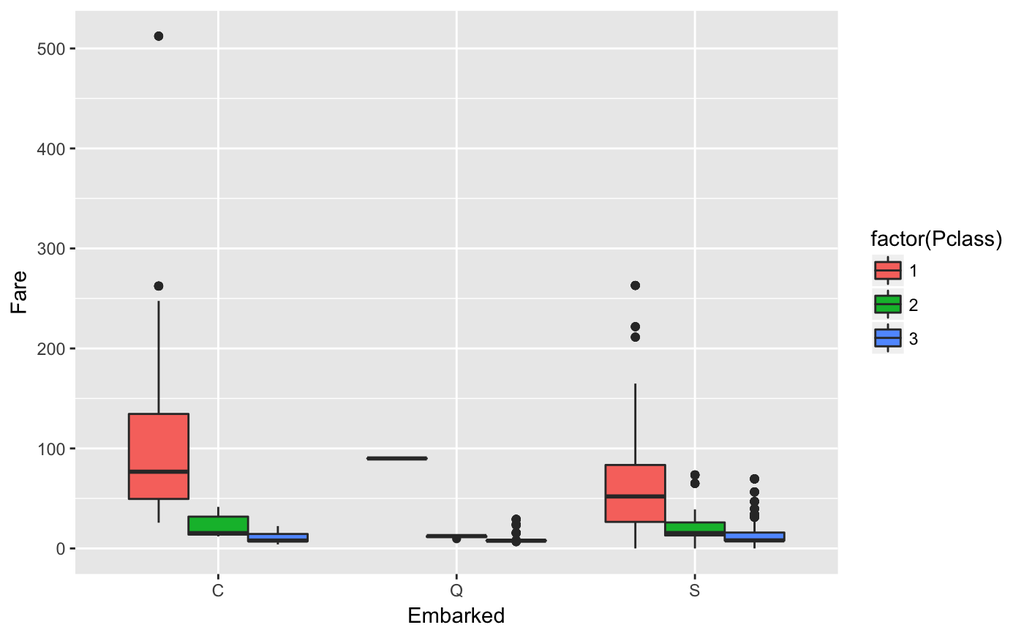

```r
ggplot(data = subset(full, !selector),
       aes(x=Embarked, y=Fare, fill=factor(Pclass))) +
    geom_boxplot() +
    scale_y_continuous()
```

```r
full %>% filter(!selector, Embarked=='C', Pclass==1) %>% select(Fare) %>% apply(2, median)
```

```
   Fare
76.7292
```

We can see that the fare these passengers paid ($80) is close to the median of what 1st class passengers from C paid, so we infer that they embarded from C (Cherbourg)

```r
full$Embarked[selector] <- 'C'
full %>% is.na() %>% colSums()
```

```
    dataset PassengerId    Survived      Pclass        Name         Sex         Age       SibSp       Parch
          0           0         418           0           0           0         263           0           0
     Ticket        Fare       Cabin    Embarked       Title     Surname       Fsize      Family      FsizeD
          0           1        1014           0           0           0           0           0           0
       Deck
       1014
```

#### Missing `Fare`

There is a passenger with missing Fare

```r
selector <- full$Fare %>% is.na()
full[selector,]
```

| dataset | PassengerId | Survived | Pclass | Name | Sex | Age | SibSp | Parch | Ticket | Fare | Cabin | Embarked | Title | Surname | Fsize | Family | FsizeD | Deck |
| --- | --- | --- | --- | --- | --- | --- | --- | --- | --- | --- | --- | --- | --- | --- | --- | --- | --- | --- |
| test | 1044 | NA | 3 | Storey, Mr. Thomas | male | 60.5 | 0 | 0 | 3701 | NA | NA | S | Mr | Storey | 1 | Storey_1 | singleton | NA |

This is a 3rd class passenger embarked form `S`. The `Fare` distribution of this group of passengers is

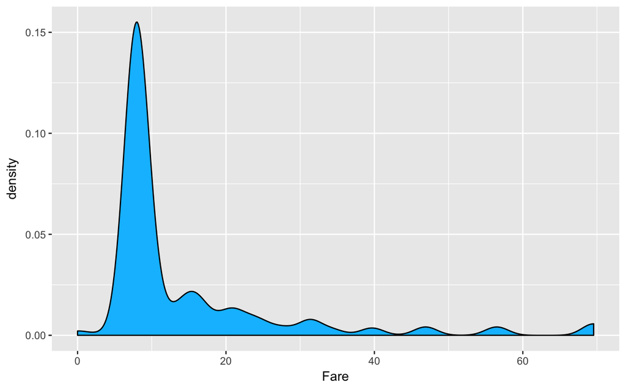

```r
group_selector <- (!selector) & (full$Embarked=='S') & (full$Pclass==3)
ggplot(data = filter(full, group_selector),
       aes(x=Fare)) +
    geom_density(fill='deepskyblue')
```

Use median fare of this class group to fill the missing fare

```r
full$Fare[selector] <- full$Fare[group_selector] %>% median()
full %>% is.na() %>% colSums()
```

```
    dataset PassengerId    Survived      Pclass        Name         Sex         Age       SibSp       Parch
          0           0         418           0           0           0         263           0           0
     Ticket        Fare       Cabin    Embarked       Title     Surname       Fsize      Family      FsizeD
          0           0        1014           0           0           0           0           0           0
       Deck
       1014
```

#### Missing `Age`

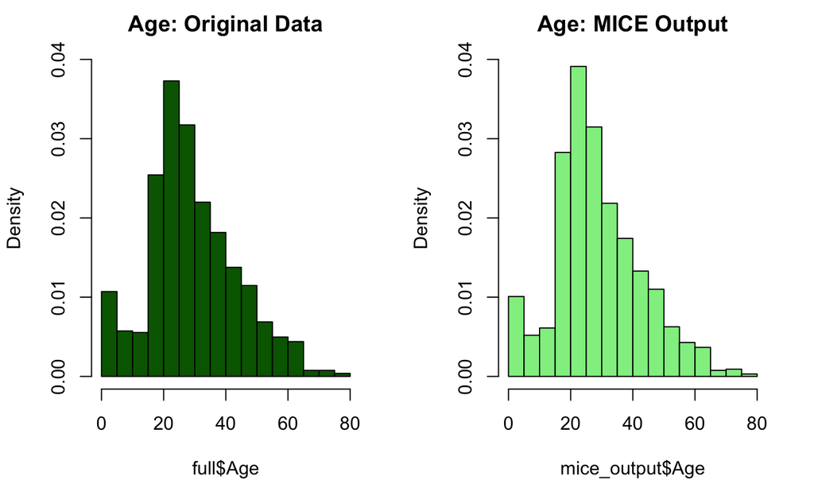

```r
par(mfrow=c(1,2))
hist(full$Age, freq = F, main='Age: Original Data', col = 'darkgreen', ylim = c(0, 0.04))
hist(mice_output$Age, freq = F, main = 'Age: MICE Output', col = 'lightgreen', ylim = c(0, 0.04))
```

Use `mice_output$Age` to replace `Age` in the original dataset.

```r
full$Age <- mice_output$Age
full$Age %>% is.na() %>% sum()
```

```
[1] 0
```

## More new features

#### Adult/child

```r
full <- full %>% mutate(Child=ifelse(Age<18, 'Child', 'Adult') %>% as.factor())
table(full$Child, full$Survived)
```

```
          0   1
  Adult 479 275
  Child  70  67
```

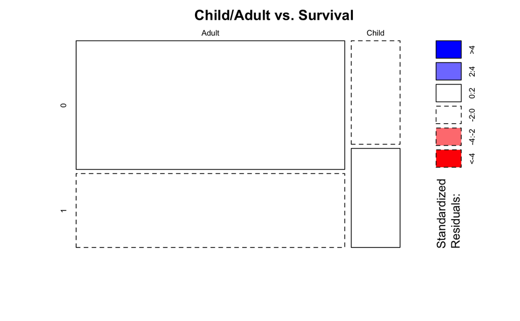

```r
mosaicplot(table(full$Child, full$Survived), shade=TRUE, main='Child/Adult vs. Survival')
```

#### Mother

```r
full <- full %>% mutate(Mother=(Sex=='female' & Parch>0 & Age>18 & Title!='Miss'))
table(full$Mother, full$Survived)
```

```
          0   1
  FALSE 534 303
  TRUE   15  39
```

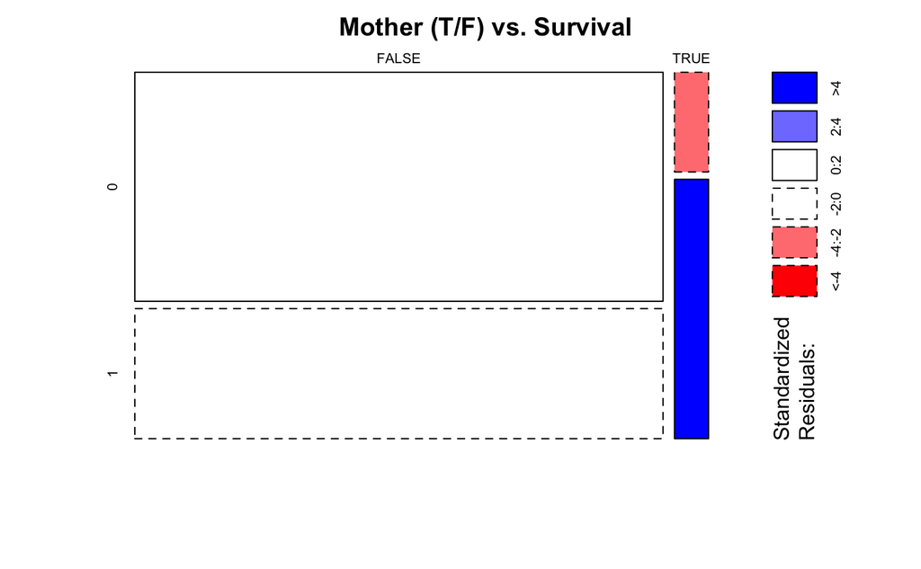

```r
mosaicplot(table(full$Mother, full$Survived), shade=TRUE, main='Mother (T/F) vs. Survival')
```

```r
full %>% is.na() %>% colSums()
```

```
    dataset PassengerId    Survived      Pclass        Name         Sex         Age       SibSp       Parch
          0           0         418           0           0           0           0           0           0
     Ticket        Fare       Cabin    Embarked       Title     Surname       Fsize      Family      FsizeD
          0           0        1014           0           0           0           0           0           0
       Deck       Child      Mother
       1014           0           0
```

## Final Cleaning: Strings to Factors

```r
cols <- c('Pclass', 'Sex', 'Embarked', 'Title', 'FsizeD', 'Child', 'Mother')
full[cols] <- full[cols] %>% lapply(factor)
sapply(full, class)
```

```
    dataset PassengerId    Survived      Pclass        Name         Sex         Age       SibSp       Parch
"character"   "integer"   "integer"    "factor" "character"    "factor"   "numeric"   "integer"   "integer"
     Ticket        Fare       Cabin    Embarked       Title     Surname       Fsize      Family      FsizeD
"character"   "numeric" "character"    "factor"    "factor" "character"   "numeric" "character"    "factor"
       Deck       Child      Mother
   "factor"    "factor"    "factor"
```

# Model

## Train-test split

Split the full dataset back into `train` and `test` sets

```r
train <- full %>% filter(dataset=='train') %>% select(-dataset)
test  <- full %>% filter(dataset=='test')  %>% select(-dataset)
```

## Random Forrest model

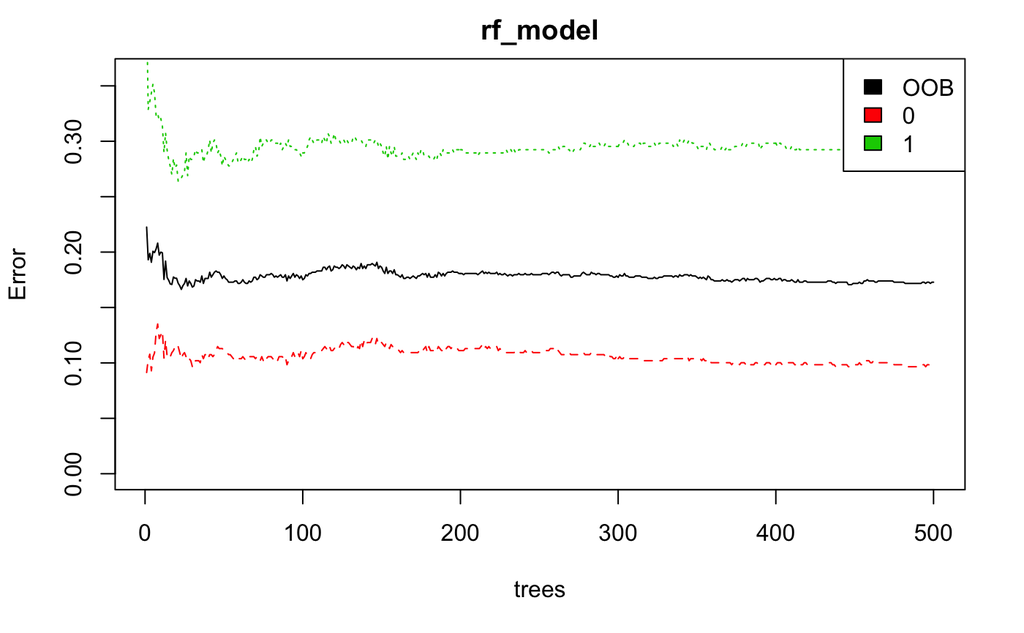

```r
set.seed(754)
rf_model <- randomForest(factor(Survived) ~ Pclass + Sex + Age + SibSp +
                                            Parch + Fare + Embarked + Title +
                                            FsizeD + Child + Mother,
                         data = train)
par(mfrow=c(1,1))
plot(rf_model, ylim=c(0, 0.36))
legend('topright', colnames(rf_model$err.rate), col = 1:3, fill = 1:3)
```

## Variable Importance

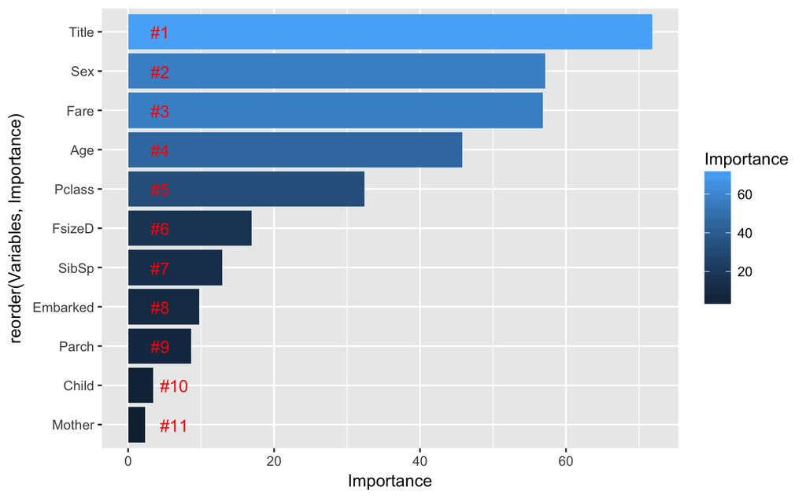

```r
importance <- importance(rf_model)
varImportance <- data.frame(Variables = row.names(importance),
                            Importance = round(importance[,'MeanDecreaseGini'], 2))
rankImportance <- varImportance %>%
    mutate(Rank = dense_rank(desc(Importance))) %>%
    arrange(Rank)
ggplot(data = rankImportance,
       aes(x = reorder(Variables, Importance), y = Importance, fill=Importance)) +
    geom_bar(stat = 'identity') +
    geom_text(aes(x=Variables, y=0.5, label=paste0('#',Rank)), hjust=-1, vjust=0.55, color='red') +
    coord_flip()
```

# Prediction

```r
pred <- predict(rf_model, test)
solution <- tibble(PassengerId = test$PassengerId, Survived = pred)
write_csv(solution, 'rf_mod_Solution.csv')
```

# Summary

## Workflow Overview

- Check data
  - Shape
  - Feature types (categorical/continuous)
  - Missing values
- Data cleaning + feature engineering
- Modeling
- Prediction

## What can be learned

- Feature engineering. E.g. extracting titles from names
- Imputation of missing data: `mice`
- Categorical features visualization with `mosaicplot()`

## What can be improved

- Model evaluation
- Random forest parameter tuning